# Differential expression analysis — ARM mutants

2026-06-20

## Introduction

Three biological replicates were analyzed for each plant line:

- **arm-YL** (arm knocked-down mutant, young leaves): SRR36181525, SRR36181534, SRR36181536
- **OeAr-7d** (ARM overexpressor, 7-day-old seedlings): SRR36181530, SRR36181531, SRR36181532
- **arm-7d** (arm knocked-down mutant, 7-day-old seedlings): SRR12606658, SRR12606657, SRR12606656
- **armtert-7d** (arm tert double mutant, 7-day-old seedlings): SRR12606655, SRR12606676, SRR12606675

Wild-type controls:

- **Columbia-0 young leaves** (Col0_YL): SRR36181526, SRR36181527, SRR36181528
- **Columbia-0 7-day-old seedlings** (Col0_7d): SRR12606666, SRR12606677, SRR12606678

### Model design

A single DESeq2 model (one factor, six levels) was fit using all 18 samples, with Col0_7d as the reference level. DEG cutoffs: adjusted p-value < 0.05 and |log2 fold change| > 1.

The following comparisons were extracted:

- arm-YL vs Columbia0-YL
- OeAr-7d vs Columbia0-7d
- arm-7d vs Columbia0-7d

## Setup — paths

```r
info_path <- "data/info_all.csv"   # 18 samples, columns: sample, genotype
result_dir <- "data/results"       # output directory
rsem_dir <- "data/rsem"            # directory containing *.genes.results files from RSEM

# DEG cutoff thresholds — adjust to control stringency
PADJ_CUTOFF <- 0.05
LFC_CUTOFF  <- 1
```

```r
dir.create(result_dir, showWarnings = FALSE)
```

## Load count data

RSEM expected counts (column 5 of *.genes.results files) are loaded and rounded to integers as required by DESeq2.

```r
setwd(rsem_dir)

files <- list.files(".", "*genes.results$", full.names = TRUE)

countData <- data.frame(fread(files[1]))[c(1, 5)]
for (i in 2:length(files)) {
  countData <- cbind(countData, data.frame(fread(files[i]))[5])
}

columns <- gsub("Aligned.toTranscriptome.out.rsem.genes.results", "", files)
columns <- gsub("./", "", columns)
colnames(countData) <- c("GeneID", columns)

rownames(countData) <- countData$GeneID
countData <- countData[, c(2:ncol(countData))]
countData <- round(countData)
colnames(countData)
```

```
##  [1] "arm-YL-1_non_rRNA"       "arm-YL-2_non_rRNA"
##  [3] "arm-YL-5_non_rRNA"       "Columbia0-YL2a_non_rRNA"
##  [5] "Columbia0-YL2K_non_rRNA" "Columbia0-YL3K_non_rRNA"
##  [7] "OeAr7d12_2_1_6_non_rRNA" "OeAr7d12_2_2_4_non_rRNA"
##  [9] "OeAr7d12_2_2_5_non_rRNA" "SRR12606655_non_rRNA"
## [11] "SRR12606656_non_rRNA"    "SRR12606657_non_rRNA"
## [13] "SRR12606658_non_rRNA"    "SRR12606666_non_rRNA"
## [15] "SRR12606675_non_rRNA"    "SRR12606676_non_rRNA"
## [17] "SRR12606677_non_rRNA"    "SRR12606678_non_rRNA"
```

```r
# Rename columns to clean sample names matching the info CSV genotype assignments.
# Files are loaded in alphabetical order by list.files(); column names must match that order exactly.
colnames(countData) <- c(
  "arm_YL_1", "arm_YL_2", "arm_YL_3",
  "Col0_YL_1", "Col0_YL_2", "Col0_YL_3",
  "OeAr_7d_1", "OeAr_7d_2", "OeAr_7d_3",
  "armtert_7d_1", "arm_7d_3", "arm_7d_2", "arm_7d_1",
  "Col0_7d_3", "armtert_7d_3", "armtert_7d_2",
  "Col0_7d_2", "Col0_7d_1"
)
```

## Model design

```r
info <- read.csv(info_path, header = TRUE, sep = ",", stringsAsFactors = FALSE)
print(info)
```

```
##          sample  genotype
## 1      arm_YL_1      armL
## 2      arm_YL_2      armL
## 3      arm_YL_3      armL
## 4     Col0_YL_1      ColL
## 5     Col0_YL_2      ColL
## 6     Col0_YL_3      ColL
## 7     OeAr_7d_1    OeAr7d
## 8     OeAr_7d_2    OeAr7d
## 9     OeAr_7d_3    OeAr7d
## 10 armtert_7d_1 ArmTert7d
## 11     arm_7d_3     arm7d
## 12     arm_7d_2     arm7d
## 13     arm_7d_1     arm7d
## 14    Col0_7d_3     Col7d
## 15 armtert_7d_3 ArmTert7d
## 16 armtert_7d_2 ArmTert7d
## 17    Col0_7d_2     Col7d
## 18    Col0_7d_1     Col7d
```

```r
dds <- DESeqDataSetFromMatrix(countData, info, ~genotype)
dds$genotype <- relevel(dds$genotype, ref = "Col7d")

# Explore model matrix
model.matrix(design(dds), colData(dds))
```

```
##              (Intercept) genotypearm7d genotypearmL genotypeArmTert7d
## arm_YL_1               1             0            1                 0
## arm_YL_2               1             0            1                 0
## arm_YL_3               1             0            1                 0
## Col0_YL_1              1             0            0                 0
## Col0_YL_2              1             0            0                 0
## Col0_YL_3              1             0            0                 0
## OeAr_7d_1              1             0            0                 0
## OeAr_7d_2              1             0            0                 0
## OeAr_7d_3              1             0            0                 0
## armtert_7d_1           1             0            0                 1
## arm_7d_3               1             1            0                 0
## arm_7d_2               1             1            0                 0
## arm_7d_1               1             1            0                 0
## Col0_7d_3              1             0            0                 0
## armtert_7d_3           1             0            0                 1
## armtert_7d_2           1             0            0                 1
## Col0_7d_2              1             0            0                 0
## Col0_7d_1              1             0            0                 0
##              genotypeColL genotypeOeAr7d
## arm_YL_1                0              0
## arm_YL_2                0              0
## arm_YL_3                0              0
## Col0_YL_1               1              0
## Col0_YL_2               1              0
## Col0_YL_3               1              0
## OeAr_7d_1               0              1
## OeAr_7d_2               0              1
## OeAr_7d_3               0              1
## armtert_7d_1            0              0
## arm_7d_3                0              0
## arm_7d_2                0              0
## arm_7d_1                0              0
## Col0_7d_3               0              0
## armtert_7d_3            0              0
## armtert_7d_2            0              0
## Col0_7d_2               0              0
## Col0_7d_1               0              0
## attr(,"assign")
## [1] 0 1 1 1 1 1
## attr(,"contrasts")
## attr(,"contrasts")$genotype
## [1] "contr.treatment"
```

## Shared functions

```r
# Annotates DESeq2 results with gene symbol and full gene name from org.At.tair.db
annotate_res <- function(df) {

  my_keys <- unique(rownames(df))
  my_col  <- c("SYMBOL", "GENENAME")

  annotation_results <- AnnotationDbi::select(
    org.At.tair.db, keys = my_keys, columns = my_col, keytype = "TAIR"
  )

  df      <- as.data.frame(df)
  df$TAIR <- rownames(df)

  merged_df <- merge(df, annotation_results, by = "TAIR", all.x = TRUE)

  unique_values <- unique(df$TAIR)

  for (tair_value in unique_values) {
    current_group <- filter(merged_df, TAIR == tair_value)

    if (any(is.na(current_group$SYMBOL))) {
      symbol <- NA
    } else if (length(current_group$SYMBOL) > 1) {
      symbol <- paste(unique(current_group$SYMBOL), collapse = ";")
    } else {
      symbol <- current_group$SYMBOL
    }

    if (any(is.na(current_group$GENENAME))) {
      genename <- NA
    } else if (length(current_group$GENENAME) > 1) {
      genename <- paste(unique(current_group$GENENAME), collapse = ";")
    } else {
      genename <- current_group$GENENAME
    }

    subset_idx <- df$TAIR == tair_value
    if (any(subset_idx)) {
      df[subset_idx, "SYMBOL"]   <- if (length(symbol) == 0)   NA else symbol
      df[subset_idx, "GENENAME"] <- if (length(genename) == 0) NA else genename
    }
  }

  return(df)
}
```

```r
# Extracts, annotates, and saves DESeq2 results for a comparison against the model's reference level.
# contr: coefficient name from resultsNames(ddsDE)
extract_res <- function(ddsDE, compare_name, contr) {
  res <- results(ddsDE, alpha = PADJ_CUTOFF, contrast = list(contr))
  res <- res[order(res$padj), ]
  res <- annotate_res(res)

  upregulated   <- subset(res, padj < PADJ_CUTOFF & log2FoldChange >  LFC_CUTOFF)
  downregulated <- subset(res, padj < PADJ_CUTOFF & log2FoldChange < -LFC_CUTOFF)

  write.csv(res,           paste0(compare_name, "_all_DESeq2.csv"))
  write.csv(upregulated,   paste0(compare_name, "_upregulated_DESeq2.csv"))
  write.csv(downregulated, paste0(compare_name, "_downregulated_DESeq2.csv"))
  return(res)
}
```

```r
# Extracts, annotates, and saves DESeq2 results for an explicit genotype-vs-genotype contrast
extract_res2 <- function(ddsDE, compare_name, contr) {
  res <- results(ddsDE, alpha = PADJ_CUTOFF, contrast = contr)
  res <- res[order(res$padj), ]
  res <- annotate_res(res)

  upregulated   <- subset(res, padj < PADJ_CUTOFF & log2FoldChange >  LFC_CUTOFF)
  downregulated <- subset(res, padj < PADJ_CUTOFF & log2FoldChange < -LFC_CUTOFF)

  write.csv(res,           paste0(compare_name, "_all_DESeq2.csv"))
  write.csv(upregulated,   paste0(compare_name, "_upregulated_DESeq2.csv"))
  write.csv(downregulated, paste0(compare_name, "_downregulated_DESeq2.csv"))
  return(res)
}
```

```r
create_volcano_plot <- function(res, title, output_file) {

  res$threshold <- factor(ifelse(
    res$padj < PADJ_CUTOFF & abs(res$log2FoldChange) > LFC_CUTOFF,
    ifelse(res$log2FoldChange > LFC_CUTOFF, "Upregulated", "Downregulated"),
    "Not Significant"
  ))

  res$padj[is.na(res$padj)] <- 1

  p <- ggplot(res, aes(x = log2FoldChange, y = -log10(padj))) +
    geom_point(aes(color = threshold), alpha = 0.8, size = 1.75) +
    scale_color_manual(values = c(
      "Upregulated"     = "red",
      "Downregulated"   = "blue",
      "Not Significant" = "grey"
    )) +
    labs(title = title, x = "Log2 Fold Change", y = "-Log10 Adjusted P-Value") +
    theme_minimal() +
    theme(
      plot.title       = element_text(hjust = 0.5, size = 16),
      axis.title       = element_text(size = 14),
      legend.title     = element_blank(),
      legend.position  = "top",
      panel.background = element_rect(fill = "white", color = NA),
      plot.background  = element_rect(fill = "white", color = NA)
    )

  print(p)
  ggsave(output_file, plot = p, width = 8, height = 6, dpi = 300)
}
```

## Differential expression

```r
dds   <- estimateSizeFactors(dds)
ddsDE <- DESeq(dds)
resultsNames(ddsDE)
```

```
## [1] "Intercept"                   "genotype_arm7d_vs_Col7d"
## [3] "genotype_armL_vs_Col7d"      "genotype_ArmTert7d_vs_Col7d"
## [5] "genotype_ColL_vs_Col7d"      "genotype_OeAr7d_vs_Col7d"
```

## Exploratory plots

```r
setwd(result_dir)

poisd <- PoissonDistance(t(counts(dds)))
samplePoisDistMatrix <- as.matrix(poisd$dd)
rownames(samplePoisDistMatrix) <- dds$sample
colnames(samplePoisDistMatrix) <- NULL
colors <- colorRampPalette(rev(brewer.pal(9, "Blues")))(255)
pheatmap(samplePoisDistMatrix,
         clustering_distance_rows = poisd$dd,
         clustering_distance_cols = poisd$dd,
         col = colors,
         filename = "sample_poisson_distance_heatmap.png",
         width = 8, height = 6, dpi = 300)

vsd   <- vst(dds)
p_pca <- plotPCA(vsd, intgroup = "sample")
```

```
## using ntop=500 top features by variance
```

```r
print(p_pca)
ggsave("PCA_plot_vst.png", plot = p_pca, width = 8, height = 6, dpi = 300)
```

[output not shown]

## Results

```r
setwd(result_dir)

res_OeAr     <- extract_res(ddsDE, "OeAr7d_vs_Col7d",     "genotype_OeAr7d_vs_Col7d")
res_arm7d    <- extract_res(ddsDE, "arm7d_vs_Col7d",       "genotype_arm7d_vs_Col7d")
res_armL <- extract_res2(ddsDE, "armL_vs_ColL", c("genotype", "armL", "ColL"))
```

## Normalized counts

```r
setwd(result_dir)
normCounts <- counts(ddsDE, normalized = TRUE)
write.csv(normCounts, "normalizedReadCounts.csv")
```

## Volcano plots

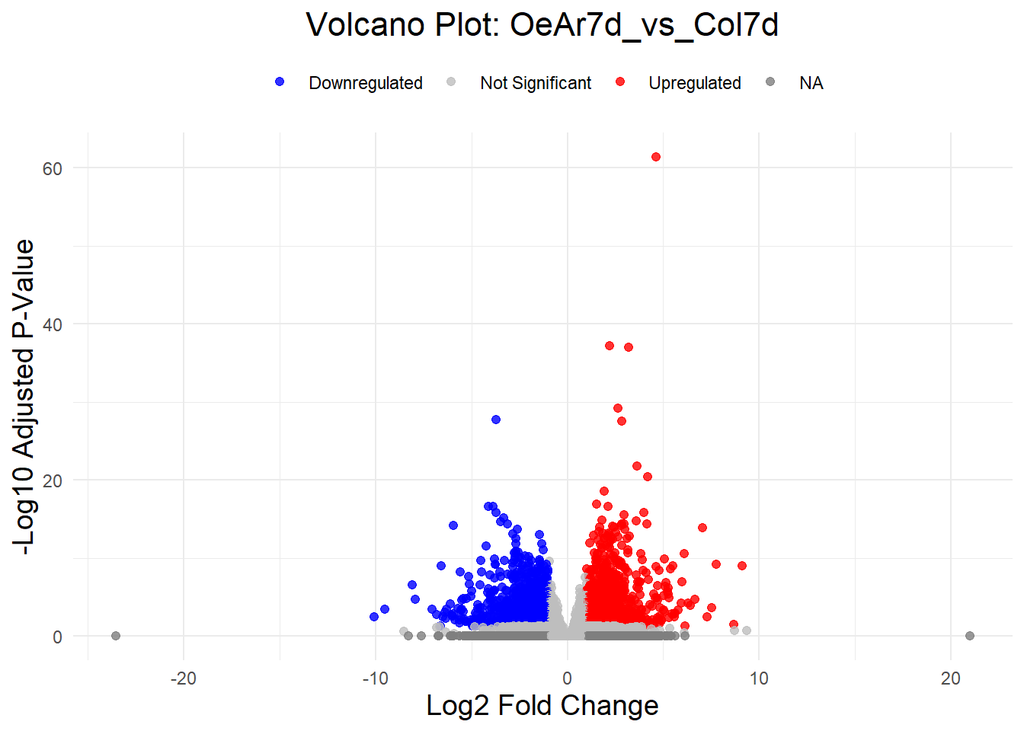

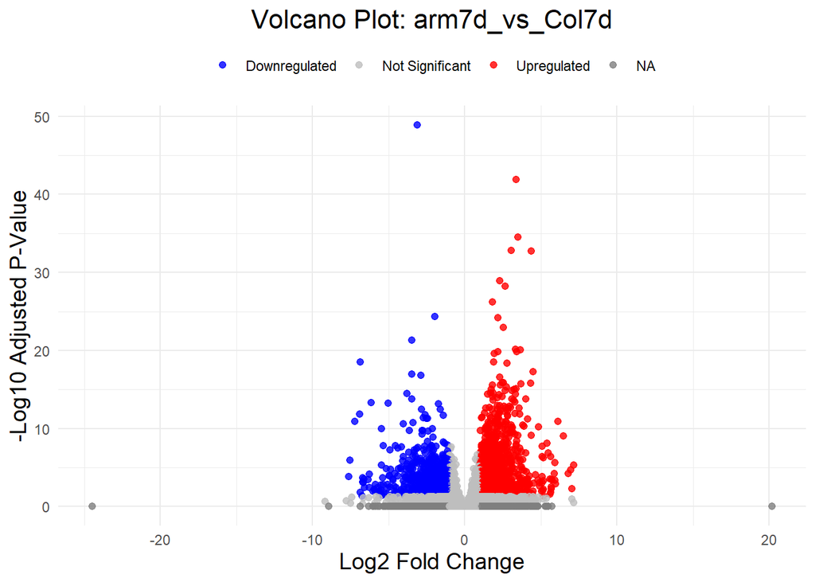

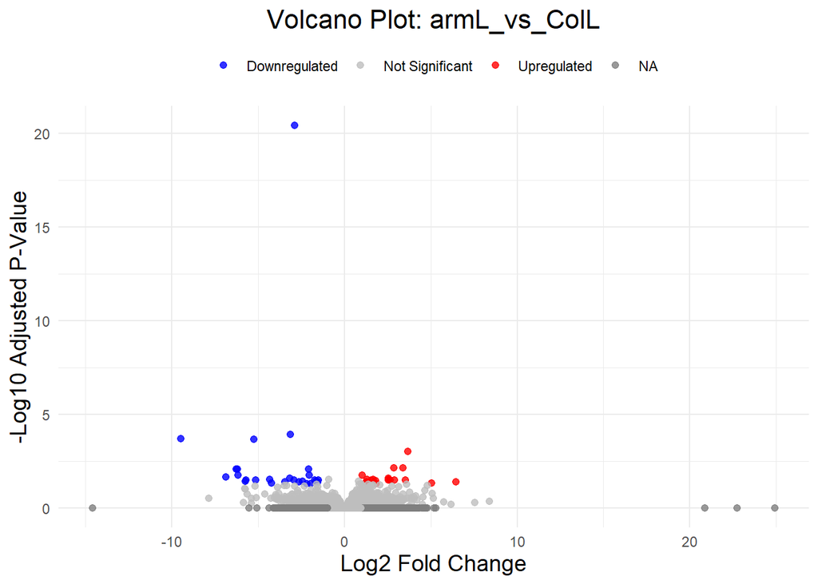

```r
setwd(result_dir)

results_list <- list(
  "OeAr7d_vs_Col7d" = res_OeAr,
  "arm7d_vs_Col7d"  = res_arm7d,
  "armL_vs_ColL"    = res_armL
)

for (name in names(results_list)) {
  create_volcano_plot(
    res         = results_list[[name]],
    title       = paste("Volcano Plot:", name),
    output_file = paste0(name, "_volcano_plot.png")
  )
}
```